# Getting started

```r
library(sapo)
library(sf)
set.seed(2024)
```

> The `sapo` package provides a Monte Carlo test for evaluating spatial association between polygons. For reproducibility, set a seed before using the functions.

This vignette illustrates the functionality of the `sapo` package. `sapo`, which is Portuguese for “toad,” stands for “**S**patial **A**ssociation Between **Po**lygons”. This package enables you to test whether two types of polygons are spatially associated. This raises two key questions: 1) What do these “polygon types” represent? and 2) What constitutes spatial association?

Polygons can represent various spatial entities. In ecology, for instance, polygons might represent ecological patches (McGarigal 2013), animal home ranges, or forest canopy gaps. It’s often important to determine if two types of spatial phenomena (like those mentioned above) tend to attract or repel each other. Conditional Monte Carlo (MC) hypothesis tests (Godoy, Assunção, and Butler 2022) offer a way to test these hypotheses. The `cmc_psat` function (conditional MC polygon association test) implements these methods. All methods are based on conditional MC simulation, generating spatial patterns that assume spatial independence (using an adaptation of the toroidal shift[^1]) while preserving the observed marginal spatial structures.

To illustrate the package’s functionality, consider two simulated polygon types, `poly1` and `poly2`, loaded below as `sf` objects. These will represent two distinct spatial features. Our goal is to test whether they are *spatially independent*.

```r
poly1 <- system.file("extdata", "poly1.rds", package = "sapo") |>
  readRDS()
poly2 <- system.file("extdata", "poly2.rds", package = "sapo") |>
  readRDS()

str(poly1)
```

```
#> Classes 'sf' and 'data.frame':   20 obs. of  2 variables:
#>  $ id      : chr  "1" "2" "3" "4" ...
#>  $ geometry:sfc_POLYGON of length 20; first list element: List of 1
#>   ..$ : num [1:7, 1:2] 0.00727 0.04896 0.07805 0.07173 0 ...
#>   ..- attr(*, "class")= chr [1:3] "XY" "POLYGON" "sfg"
#>  - attr(*, "sf_column")= chr "geometry"
#>  - attr(*, "agr")= Factor w/ 3 levels "constant","aggregate",..:
#>   ..- attr(*, "names")= chr(0)
```

```r
str(poly2)
```

```
#> Classes 'sf' and 'data.frame':   25 obs. of  2 variables:
#>  $ id      : chr  "1" "2" "3" "4" ...
#>  $ geometry:sfc_POLYGON of length 25; first list element: List of 1
#>   ..$ : num [1:5, 1:2] 0.6 0.7 0.7 0.6 0.6 0.3 0.3 0.4 0.4 0.3
#>   ..- attr(*, "class")= chr [1:3] "XY" "POLYGON" "sfg"
#>  - attr(*, "sf_column")= chr "geometry"
#>  - attr(*, "agr")= Factor w/ 3 levels "constant","aggregate",..:
#>   ..- attr(*, "names")= chr(0)
```

Below, we plot these polygon types from this toy example.

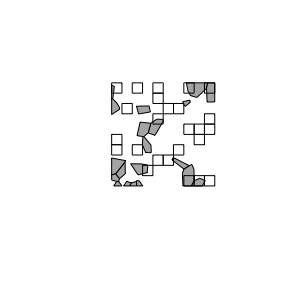

```r
plot(sf::st_geometry(poly1), col = "gray70")
plot(sf::st_geometry(poly2), add = TRUE)
```

The `cmc_psat` function requires that its first two arguments, `p1` and `p2`, are `sf` objects. Other important arguments include:

- `n_sim` (default = 499): An integer specifying the number of conditional MC simulations under the null hypothesis of spatial independence.
- `alpha` (default = 0.05): A real number (between 0 and 1) indicating the significance level for the hypothesis test.

For a deeper understanding of the remaining arguments, refer to Godoy, Assunção, and Butler (2022), which provides a comprehensive explanation of the method. The default argument values generally optimize the test’s power and type I error rate.

The code below tests whether `poly1` and `poly2` are *spatially independent*. In essence, it assesses whether the presence of a type 2 polygon affects the likelihood of observing a type 1 polygon.

```r
my_ht <- cmc_psat(poly1, poly2)
```

[output not shown]

[output cut: 943 more lines]

[output not shown]

The test’s p-value is 0.0720, indicating a lack of spatial dependence. If the analysis suggests that the polygons are not spatially independent, a descriptive analysis can be performed using a generalization of the $H_{12}$ function (typically $K_{12}$ or $L_{12}$, with the latter being the package default) used for analyzing spatial point patterns.

We’ll now create point-wise confidence bands based on the $L_{12}$ null hypothesis. These bands will be plotted against the $L_{12}$ function calculated from the real data. A significant result with the black curve (representing the real data) below the envelope suggests that the two polygon types repel each other. Conversely, if the black curve is above the envelope, it indicates attraction. Remember that these envelopes are for descriptive analysis, not inference. The *p-value* determines whether to reject the hypothesis of spatial independence.

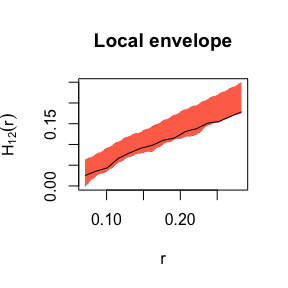

```r
sig_level <- my_ht$alpha
sig_plot <-
  data.frame(r = my_ht$distances,
             h = my_ht$mc_funct[NROW(my_ht$mc_funct), ],
             l = apply(my_ht$mc_funct, 2, quantile,
                       prob = .5 * sig_level),
             u = apply(my_ht$mc_funct, 2, quantile,
                       prob = 1 - .5 * sig_level))
## par(mfrow = c(1, 2))
## ## plot density part
## den <- density(my_ht$mc_sample)
## plot(den, main = sprintf("Test statistic (p-value = %.4f)",
##                          my_ht$p_value),
##      xlab = "u", ylab = "density")
## value <- my_ht$mc_sample[length(my_ht$mc_sample)]
## polygon(c(den$x[den$x >= value], value),
##         c(den$y[den$x >= value], 0),
##         col = "coral1",
##         border = "transparent")
## lines(den)
## H function
with(sig_plot, plot(x = r, y = h, type = "l",
                    col = 2,
                    main = "Local envelope",
                    xlab = "r",
                    ylab = expression(H[12](r)),
                    ylim = range(c(h, l, u))))
with(sig_plot, lines(x = r, y = l, lty = 2, col = 2))
with(sig_plot, lines(x = r, y = u, lty = 2, col = 2))
with(sig_plot,
     polygon(c(r, rev(r)), c(l, rev(u)),
             col = "coral1", lty = 0))
with(sig_plot, lines(x = r, y = h,
                     col = 1))
```

Godoy, Lucas da Cunha, Renato Martins Assunção, and Kevin A. Butler. 2022. “Testing the Spatial Association of Different Types of Polygons.” *Spatial Statistics* 51: 100695. https://doi.org/https://doi.org/10.1016/j.spasta.2022.100695.

McGarigal, Kevin. 2013. “Landscape Pattern Metrics.” In *Encyclopedia of Environmetrics*. John Wiley & Sons, Ltd. https://doi.org/https://doi.org/10.1002/9780470057339.val006.pub2.

[^1]: a technique that shifts the polygons to simulate different spatial arrangements